# Homework 4

Monirul Islam

2024-05-02

## Question 1

### (Q1a) Find the maximum element of a vector (only using loops, conditionals, and Boolean operators - no max, min, sort or similar).

```r
mymax <-function(vector) {
  max_element = vector[1]
  for (element in length(vector)) {
    if (vector[element] > max_element) {
      max_element = vector[element]
    }
  }
  print(max_element)
}
```

```r
mymax(c(3, 4, 5))
```

```
## [1] 5
```

```r
mymax(c(-1, 0, 0, 4))
```

```
## [1] 4
```

```r
mymax(c(3, 2, 3))
```

```
## [1] 3
```

### (Q1b) State the current date and time:

```r
when <- function() {
  time = strftime(Sys.time(), "%I:%M%P on %A, %B %dth, %Y")
  print(paste('It is',paste0(time,'.')))
}
```

```r
when()
```

```
## [1] "It is 03:19am on Thursday, December 19th, 2024."
```

### (Q1c) Make random ‘Secret Santa’ assignments: that is, take a list of n elements, and randomly map each element to another element without mapping any element to itself.

```r
secret_santa <-function(n) {
  repeat {
    random = sample(n)
    if (all(!(n == random))) {
      break
    }
  }
  secret_santa_table <- data.frame(Giver = n, Recipient = random)
  print(secret_santa_table)
}
```

```r
secret_santa(c("Michael", "Gus", "Elizabeth", "Mary"))
```

```
##       Giver Recipient
## 1   Michael       Gus
## 2       Gus      Mary
## 3 Elizabeth   Michael
## 4      Mary Elizabeth
```

### (Q1d) Find the longest string in a character vector: the nchar function may be helpful here.

```r
longest_str <- function(vector) {
  max_length = max(nchar(vector))
  print(vector[nchar(vector) == max_length])
}
```

```r
longest_str(c("Elizabeth", "Michael", "Mary", "Gus"))
```

```
## [1] "Elizabeth"
```

```r
longest_str(c("Baruch", "Hunter", "John Jay"))
```

```
## [1] "John Jay"
```

### (Q1e) Convert a temperature in Fahrenheit to Celsius:

```r
f2c <- function(f) {
  c = (5/9)*(f-32)
  print(c)
}
```

```r
f2c(32)
```

```
## [1] 0
```

```r
f2c(212)
```

```
## [1] 100
```

```r
f2c(-40)
```

```
## [1] -40
```

## Question 2

```r
data(babynames)
glimpse(babynames)
```

```
## Rows: 1,924,665
## Columns: 5
## $ year <dbl> 1880, 1880, 1880, 1880, 1880, 1880, 1880, 1880, 1880, 1880, 1880,…
## $ sex  <chr> "F", "F", "F", "F", "F", "F", "F", "F", "F", "F", "F", "F", "F", …
## $ name <chr> "Mary", "Anna", "Emma", "Elizabeth", "Minnie", "Margaret", "Ida",…
## $ n    <int> 7065, 2604, 2003, 1939, 1746, 1578, 1472, 1414, 1320, 1288, 1258,…
## $ prop <dbl> 0.07238359, 0.02667896, 0.02052149, 0.01986579, 0.01788843, 0.016…
```

### (Q2a) In how many different years was ‘Michael’ the most common boys’ name?

```r
Michael <- babynames |> group_by(year) |> filter(sex == "M", n == max(n), name == "Michael")
Michael
```

```
## # A tibble: 44 × 5
## # Groups:   year [44]
##     year sex   name        n   prop
##    <dbl> <chr> <chr>   <int>  <dbl>
##  1  1954 M     Michael 88514 0.0428
##  2  1955 M     Michael 88335 0.0423
##  3  1956 M     Michael 90620 0.0423
##  4  1957 M     Michael 92695 0.0424
##  5  1958 M     Michael 90520 0.0420
##  6  1959 M     Michael 85255 0.0394
##  7  1961 M     Michael 86922 0.0403
##  8  1962 M     Michael 85037 0.0405
##  9  1963 M     Michael 83789 0.0406
## 10  1964 M     Michael 82653 0.0408
## # ℹ 34 more rows
```

44 years where “Michael” was the most common boys name.

### (Q2b) In what year was the first child named ‘Daddy’ born?

```r
Daddy <- babynames |> filter(name == "Daddy") |> arrange(year) |> head(n=1)
Daddy
```

```
## # A tibble: 1 × 5
##    year sex   name      n       prop
##   <dbl> <chr> <chr> <int>      <dbl>
## 1  2005 M     Daddy    14 0.00000659
```

### (Q2c) In what year, did the top 5 girls names comprise the highest fraction of total births?

```r
total_births <- babynames |>
  group_by(year) |>
  summarise(total_births = sum(births))

top_five_girlsNames <- babynames |>
  filter(sex == 'F') |>
  group_by(year) |>
  arrange(desc(n)) |>
  slice_max(n, n=5,with_ties = FALSE) |>
  summarise(top_5 = sum(n))

top5_totalBirths <- inner_join(top_five_girlsNames,total_births,join_by(year)) |>
  mutate(frac = top_5/total_births) |>
  arrange(desc(frac)) |>
  head(n=1)
top5_totalBirths
```

```
## # A tibble: 1 × 4
##    year  top_5 total_births     frac
##   <dbl>  <int>        <int>    <dbl>
## 1  1947 306217    379399491 0.000807
```

### (Q2d) What name has been given to more girls than any other?

```r
girl <- babynames |> filter(sex == "F") |>
  group_by(name) |>
  summarise(total = sum(n)) |>
  arrange(desc(total)) |>
  head(n=1)
girl
```

```
## # A tibble: 1 × 2
##   name    total
##   <chr>   <int>
## 1 Mary  4123200
```

### (Q2e) In what decade were the most ”Adolph”s born in the US? (You will need to use a mutate to create a new decade variable.)

```r
Adolph <- babynames |>
  filter(name == "Adolph") |>
  mutate(decade = 10 * (year %/% 10)) |>
  group_by(decade) |>
  summarise(total = sum(n)) |>
  arrange(desc(total)) |>
  head(n=1)
Adolph
```

```
## # A tibble: 1 × 2
##   decade total
##    <dbl> <int>
## 1   1910  4531
```

## Question 3

```r
data(cdiac)
glimpse(cdiac)
```

```
## Rows: 166
## Columns: 14
## $ year   <int> 1850, 1851, 1852, 1853, 1854, 1855, 1856, 1857, 1858, 1859, 186…
## $ jan    <dbl> -0.702, -0.303, -0.308, -0.177, -0.360, -0.176, -0.119, -0.512,…
## $ feb    <dbl> -0.284, -0.362, -0.477, -0.330, -0.280, -0.400, -0.373, -0.344,…
## $ mar    <dbl> -0.732, -0.485, -0.505, -0.318, -0.284, -0.303, -0.513, -0.434,…
## $ apr    <dbl> -0.570, -0.445, -0.559, -0.352, -0.349, -0.217, -0.371, -0.646,…
## $ may    <dbl> -0.325, -0.302, -0.209, -0.268, -0.230, -0.336, -0.119, -0.567,…
## $ jun    <dbl> -0.213, -0.189, -0.038, -0.179, -0.215, -0.160, -0.288, -0.310,…
## $ jul    <dbl> -0.128, -0.215, -0.016, -0.059, -0.228, -0.268, -0.297, -0.544,…
## $ aug    <dbl> -0.233, -0.153, -0.195, -0.148, -0.163, -0.159, -0.305, -0.327,…
## $ sep    <dbl> -0.444, -0.108, -0.125, -0.409, -0.115, -0.339, -0.459, -0.393,…
## $ oct    <dbl> -0.452, -0.063, -0.216, -0.359, -0.188, -0.211, -0.384, -0.467,…
## $ nov    <dbl> -0.190, -0.030, -0.187, -0.256, -0.369, -0.212, -0.608, -0.665,…
## $ dec    <dbl> -0.268, -0.067, 0.083, -0.444, -0.232, -0.510, -0.440, -0.356, …
## $ annual <dbl> -0.375, -0.223, -0.224, -0.271, -0.246, -0.271, -0.352, -0.460,…
```

### (Q3a) Plot the estimated annual global mean temperature (GMT) anomaly from 1850 to 2015.

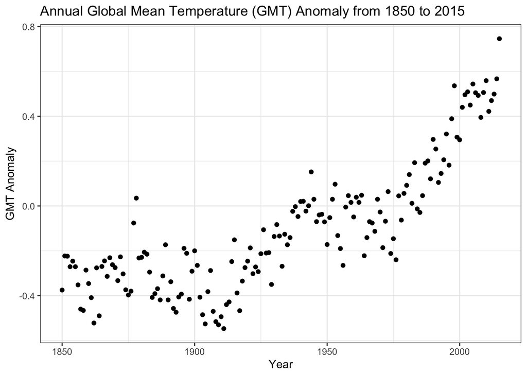

```r
ggplot(cdiac, aes(x=year,y=annual)) +
  geom_point() +
  theme_bw() +
  ggtitle("Annual Global Mean Temperature (GMT) Anomaly from 1850 to 2015") +
  xlab("Year") +
  ylab("GMT Anomaly")
```

### (Q3b) Plot the GMT anomaly for each month on the same plot (as different lines).

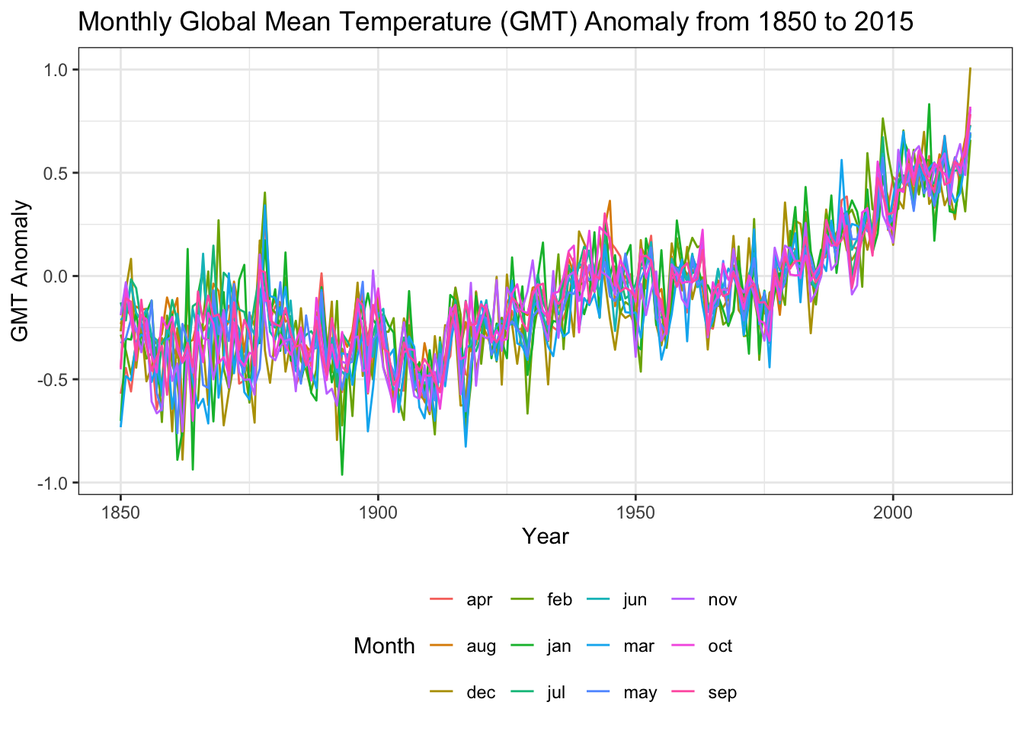

```r
cdiac_longer <- cdiac |>
  pivot_longer(cols = "jan":"dec", names_to = "Month", values_to = "GMT") |>
  select(-annual)
ggplot(cdiac_longer, aes(x=year, y=GMT, color=Month)) +
  geom_line() +
  theme_bw() +
  ggtitle("Monthly Global Mean Temperature (GMT) Anomaly from 1850 to 2015") +
  xlab("Year") +
  ylab("GMT Anomaly") +
  theme(legend.position = 'bottom') +
  theme(legend.key.width = unit(.5,'cm'))
```

### (Q3c) Plot the monthly GMT anomaly series as one long line (with a point for each month).

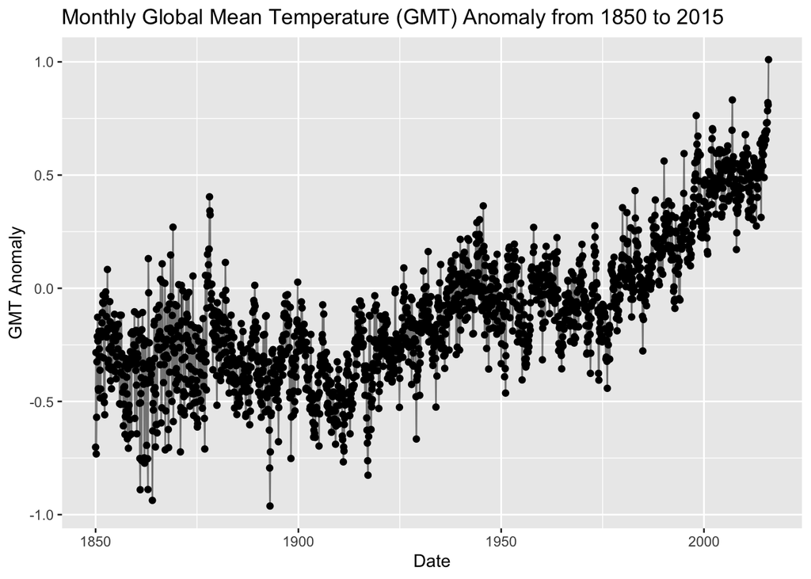

```r
cdiac_longer_formatted <- cdiac_longer |>
  mutate(Date = as.Date(paste(Month, "1", year, sep = "-"), format = "%b-%d-%Y")) |>
  select(Date, GMT)

ggplot(cdiac_longer_formatted, aes(x = Date, y = GMT)) +
  geom_point() +
  geom_line(alpha=0.5) +
  ggtitle("Monthly Global Mean Temperature (GMT) Anomaly from 1850 to 2015") +
  ylab("GMT Anomaly")
```

### (Q3d) Now focus only on July: plot the July GMT anomaly series. Use the runmed function to add a second series to the plot giving the median July GMT anomaly of the previous 5 years. Is there evidence of an increasing warming trend?

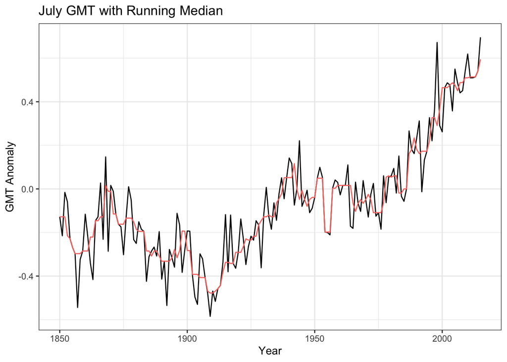

```r
July <- cdiac |> select(year,jul) |> mutate(median_jul = runmed(jul, k=5))
ggplot(July, aes(x=year)) +
  geom_line(aes(y=jul)) +
  geom_line(aes(y=median_jul,color="red")) +
  xlab("Year") +
  ylab("GMT Anomaly") +
  theme_bw() +
  theme(legend.position = 'none') +
  ggtitle("July GMT with Running Median")
```

The lines following the same direction can be evidence of an increasing warming trend.

### (Q3e) For each year, identify the warmest month (as measured by GMT anomaly); create a histogram showing the probability a given month was the hottest in its year. Make sure your x-axis is in reasonable (chronological) order - not alphabetical.

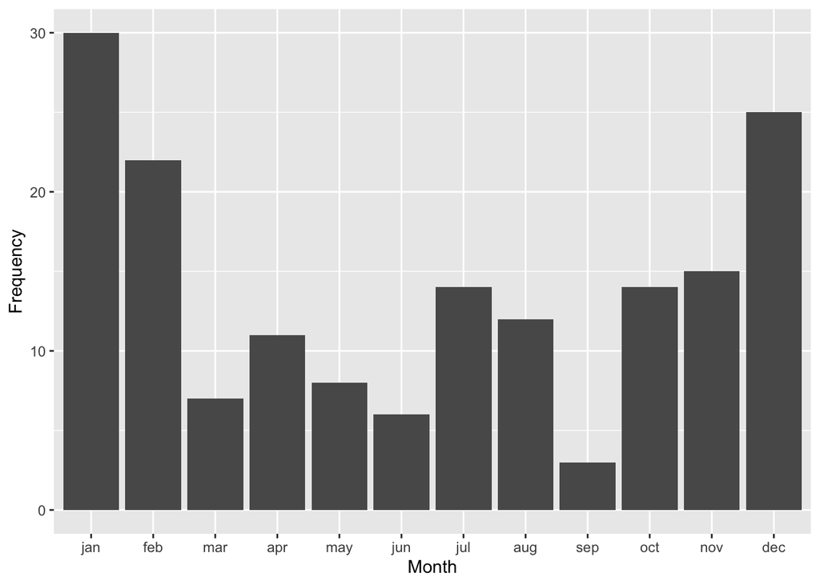

```r
warmest_months <- cdiac_longer |>
  group_by(year) |>
  filter(GMT == max(GMT))
warmest_months$Month = factor(warmest_months$Month,
levels = c("jan","feb","mar","apr", "may","jun","jul","aug","sep","oct","nov","dec"))

ggplot(warmest_months , aes(x=Month)) +
  geom_histogram(stat = 'count') +
  ylab("Frequency") +
  scale_x_discrete(limits = levels(warmest_months$Month))
```

## Question 4

### (Q4a) In the following sentence, extract all plural nouns

```r
todo1 <- "Yesterday, I needed to buy four cups of flour, a piece of Parmesean cheese,
two gallons of ice cream, and a six-pack of bottled (non-alcoholic) beers."
```

```r
str_extract_all(todo1, "\\b\\w+s\\b")
```

```
## [[1]]
## [1] "cups"    "gallons" "beers"
```

### (Q4b) In the following sentence, compute the total number of fruits on my shopping list:

```r
todo2 <- "Today, I need to purchase 3 apples, 5 limes, and 2 lemons."
```

```r
digits <- str_extract_all(todo2, "\\b[:digit:]\\b")
sum(as.numeric(unlist(digits)))
```

```
## [1] 10
```

### (Q4c) In the first page of her Wikipedia page, how many times does Taylor Swift’s last name appear?

```r
taylor <- "Taylor Alison Swift (born December 13, 1989) is an American singer-songwriter.
A subject of widespread public interest, she has influenced the music industry
and popular culture through her artistry, especially in songwriting, and entrepreneurship.
She is an advocate of artists rights and womens empowerment. Swift began professional
songwriting at age 14. She signed with Big Machine Records in 2005 and achieved
prominence as a country pop singer with the albums Taylor Swift (2006) and Fearless
(2008). Their singles ’Teardrops on My Guitar’, ’Love Story’, and ’You Belong
with Me’ were crossover successes on country and pop radio formats and brought
Swift mainstream fame. She experimented with rock and electronic styles on her
next albums, Speak Now (2010) and Red (2012), respectively, with the latter featuring
her first Billboard Hot 100 number-one single, ’We Are Never Ever Getting Back
Together’. Swift recalibrated her image from country to pop with 1989 (2014),
a synth-pop album containing the chart-topping songs ’Shake It Off’, ’Blank Space’,
and ’Bad Blood’. Media scrutiny inspired the hip-hop-influenced Reputation (2017)
and its number-one single ’Look What You Made Me Do’. After signing with Republic
Records in 2018, Swift released the eclectic pop album Lover (2019) and the autobiographical
documentary Miss Americana (2020). She explored indie folk styles on the 2020
albums Folklore and Evermore, subdued electropop on Midnights (2022), and re-recorded
four albums subtitled Taylors Version after a dispute with Big Machine. These
albums spawned the number-one songs ’Cruel Summer’, ’Cardigan’, ’Willow’, ’Anti-Hero’,
’All Too Well’, and ’Is It Over Now?’. Her Eras Tour (2023-2024) and its accompanying
concert film became the highest-grossing tour and concert film of all time, respectively.
Swift has directed videos and films such as Folklore: The Long Pond Studio Sessions
(2020) and All Too Well: The Short Film (2021). Swift is one of the worlds best-selling
artists, with 200 million records sold worldwide as of 2019. She is the most-streamed
artist on Spotify, the highest-grossing female touring act, and the first billionaire
with music as the main source of income. Six of her albums have opened with over
one million sales in a week. The 2023 Time Person of the Year, Swift has appeared
on lists such as Rolling Stones 100 Greatest Songwriters of All Time, Billboards
Greatest of All Time Artists, and Forbes Worlds 100 Most Powerful Women. Her
accolades include 14 Grammy Awards, a Primetime Emmy Award, 40 American Music
Awards, 39 Billboard Music Awards, and 23 MTV Video Music Awards; she has won
the Grammy Award for Album of the Year, the MTV Video Music Award for Video of
the Year, and the IFPI Global Recording Artist of the Year a record four times
each."
```

```r
str_count(taylor, "Swift")
```

```
## [1] 9
```

### (Q4d) In the above quote, how many different years (strings of exactly 4 digits) appear?

```r
unique(unlist(str_extract_all(taylor, "\\b\\d{4}\\b")))
```

```
##  [1] "1989" "2005" "2006" "2008" "2010" "2012" "2014" "2017" "2018" "2019"
## [11] "2020" "2022" "2023" "2024" "2021"
```

### (Q4e) Extract the names of all songs mentioned in the biography above. (Note that song names are surrounded by single quotes.)

```r
str_extract_all(taylor,'’(.*?)’')
```

```
## [[1]]
##  [1] "’Teardrops on My Guitar’"   "’Love Story’"
##  [3] "’Shake It Off’"             "’Blank Space’"
##  [5] "’Bad Blood’"                "’Look What You Made Me Do’"
##  [7] "’Cruel Summer’"             "’Cardigan’"
##  [9] "’Willow’"                   "’Anti-Hero’"
## [11] "’All Too Well’"             "’Is It Over Now?’"
```

## Question 5

### (Q5a) How many quotes are on this website?

```r
BASE_URL <- "https://quotes.toscrape.com/"
BASE_HTML <- read_html("https://quotes.toscrape.com/")
all_quotes_website <- function(BASE_HTML) {
  page_number = 1
  all_quotes = character()
  while (TRUE) {
    all_URLs <- read_html(paste0(BASE_HTML, "page/", page_number))
    quotes <- all_URLs |>
              html_elements(".quote") |>
              html_text(trim = TRUE)
    if (length(quotes) == 0) {
      break
    }
    all_quotes = c(all_quotes,quotes)
    page_number = page_number + 1
  }
  all_quotes
}
```

```r
length(all_quotes_website(BASE_URL))
```

```
## [1] 100
```

### (Q5b) How many quotes are tagged ‘Death’?

```r
all_tags_website <- function(BASE_HTML) {
  page_number = 1
  all_tags = character()
  while (TRUE) {
    all_URLs <- read_html(paste0(BASE_HTML, "page/", page_number))
    tags <- all_URLs |>
      html_elements(".tags") |>
      html_text(trim = TRUE)
    if (length(tags) == 0) {
      break
    }
    all_tags = c(all_tags,tags)
    page_number = page_number + 1
  }
  all_tags
}
```

```r
sum(str_detect(all_tags_website(BASE_URL), "death\n"))
```

```
## [1] 3
```

### (Q5c) What is the longest quote (by number of characters)?

```r
all_text_website <- function(BASE_HTML) {
  page_number = 1
  all_texts = character()
  while (TRUE) {
    all_URLs <- read_html(paste0(BASE_HTML, "page/", page_number))
    texts <- all_URLs |>
      html_elements(".text") |>
      html_text(trim = TRUE)
    if (length(texts) == 0) {
      break
    }
    all_texts = c(all_texts,texts)
    page_number = page_number + 1
  }
  all_texts
}
```

```r
which.max(nchar(all_text_website(BASE_URL)))
```

```
## [1] 11
```

```r
max(nchar(all_text_website(BASE_URL)))
```

```
## [1] 1084
```

### (Q5d) How many quotes are by (or at least are attributed to) Albert Einstein?

```r
all_author_website <- function(BASE_HTML) {
  page_number = 1
  all_authors = character()
  while (TRUE) {
    all_URLs <- read_html(paste0(BASE_HTML, "page/", page_number))
    authors <- all_URLs |>
      html_elements(".author") |>
      html_text(trim = TRUE)
    if (length(authors) == 0) {
      break
    }
    all_authors = c(all_authors,authors)
    page_number = page_number + 1
  }
  all_authors
}
```

```r
sum(str_detect(all_author_website(BASE_URL), "Albert Einstein"))
```

```
## [1] 10
```

## Question 6

### (Q6a) Jack London uses the word ‘should’ an average of three or more times per chapter.

```r
London_should <- authors |> filter(Author == "London") |> summarise(avg_should = mean(should))
London_should
```

```
##   avg_should
## 1  0.7804054
```

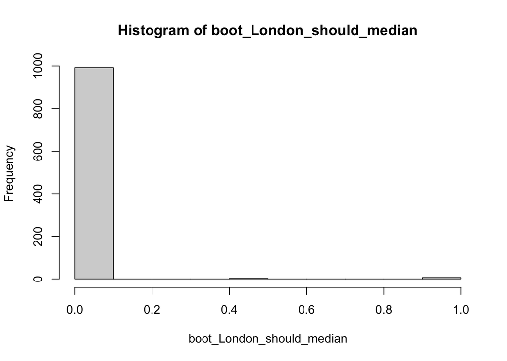

```r
London_should_table <- authors |> filter(Author == "London") |> select(should,Author)
boot_London_should_median <- replicate(1000,{
  n_rows <- NROW(London_should_table)
  London_should_table |>
    sample_n(n_rows, replace = TRUE) |>
    summarize(median_should = median(should)) |>
    pull(median_should)
})
hist(boot_London_should_median)
```

According to the mean and bootstrap model with median, London does not use the word ‘should’ on average three times or more.

### (Q6b) Jane Austen uses the word ‘her’ more than any of the other authors.

```r
her_table <- authors |>
  select(her, Author) |>
  mutate(Author = case_when(Author == "Austen" ~ Author, TRUE ~ "Other"))
t.test(her~Author, data = her_table)
```

```
##
##  Welch Two Sample t-test
##
## data:  her by Author
## t = 25.517, df = 493.81, p-value < 2.2e-16
## alternative hypothesis: true difference in means between group Austen and group Other is not equal to 0
## 95 percent confidence interval:
##  21.07969 24.59671
## sample estimates:
## mean in group Austen  mean in group Other
##            30.334385             7.496183
```

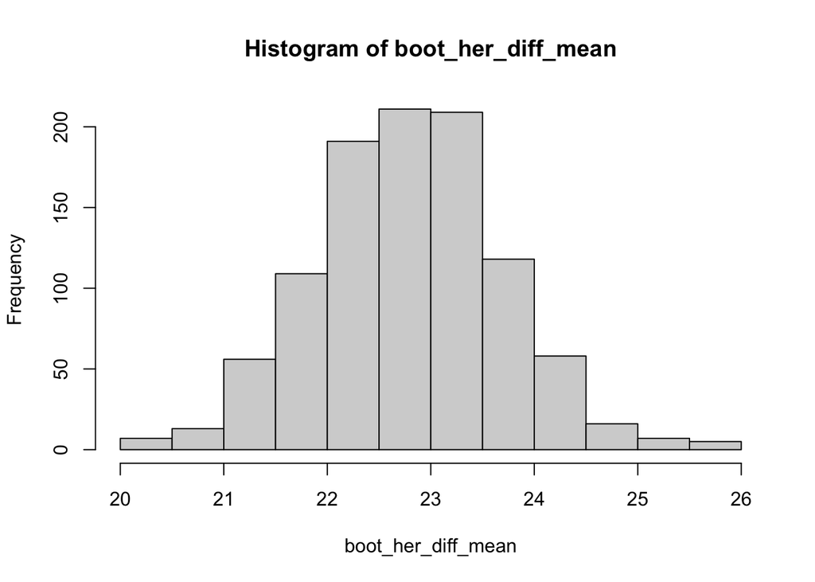

```r
boot_her_diff_mean <- replicate(1000,{
  n_rows <- NROW(her_table)
  her_table |>
    sample_n(n_rows, replace = TRUE) |>
    group_by(Author) |>
    summarize(mean_her = mean(her)) |>
    arrange(desc(Author)) |>
    pull(mean_her) |>
    diff()
})
hist(boot_her_diff_mean)
```

```r
sd(boot_her_diff_mean)
```

```
## [1] 0.9104391
```

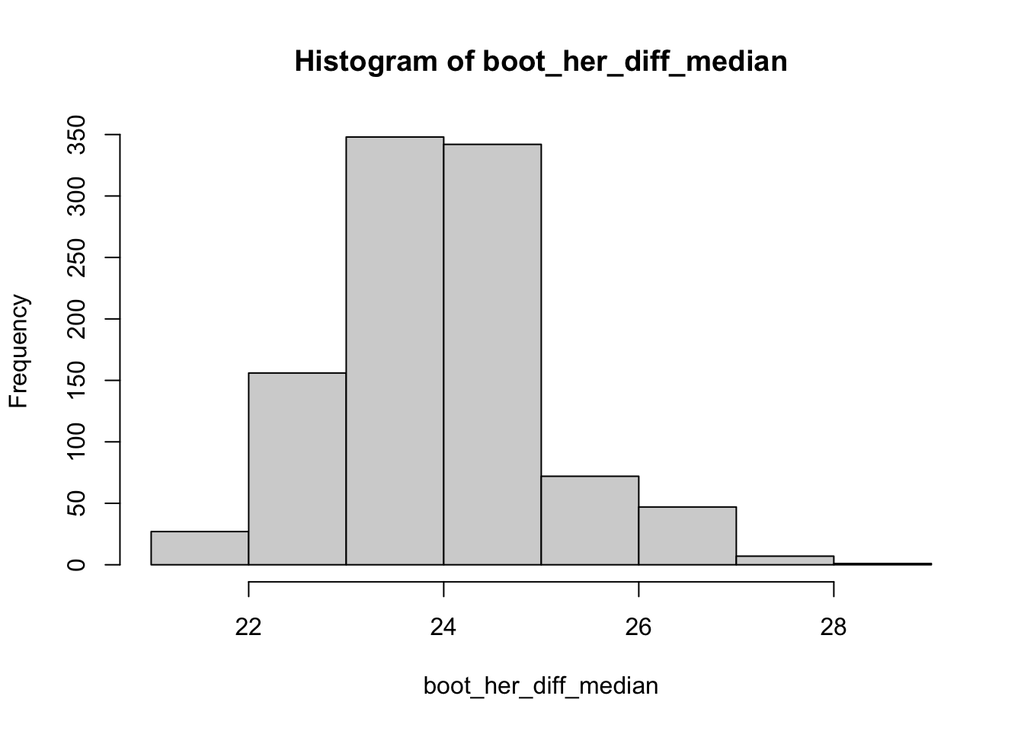

```r
boot_her_diff_median <- replicate(1000,{
  n_rows <- NROW(her_table)
  her_table |>
    sample_n(n_rows, replace = TRUE) |>
    group_by(Author) |>
    summarize(median_her = median(her)) |>
    arrange(desc(Author)) |>
    pull(median_her) |>
    diff()
})
hist(boot_her_diff_median)
```

The t-test and bootstrap models support the hypothesis that Jane Austen uses ‘her’ more than any other author. Austen’s average use of ‘her’ is about 30 while the other authors average about 7. The small p-value supports the alternative hypothesis that the true difference in means between group Austen and group Other (other authors) is not equal to 0.

### (Q6c) Jack London and John Milton use the word ‘also’ the same amount.

```r
London_Milton_also <- authors |> filter(Author %in% c("London","Milton")) |> select(also,Author)
t.test(also ~ Author, data = London_Milton_also)
```

```
##
##  Welch Two Sample t-test
##
## data:  also by Author
## t = -0.67957, df = 82.681, p-value = 0.4987
## alternative hypothesis: true difference in means between group London and group Milton is not equal to 0
## 95 percent confidence interval:
##  -0.3574782  0.1754143
## sample estimates:
## mean in group London mean in group Milton
##            0.7635135            0.8545455
```

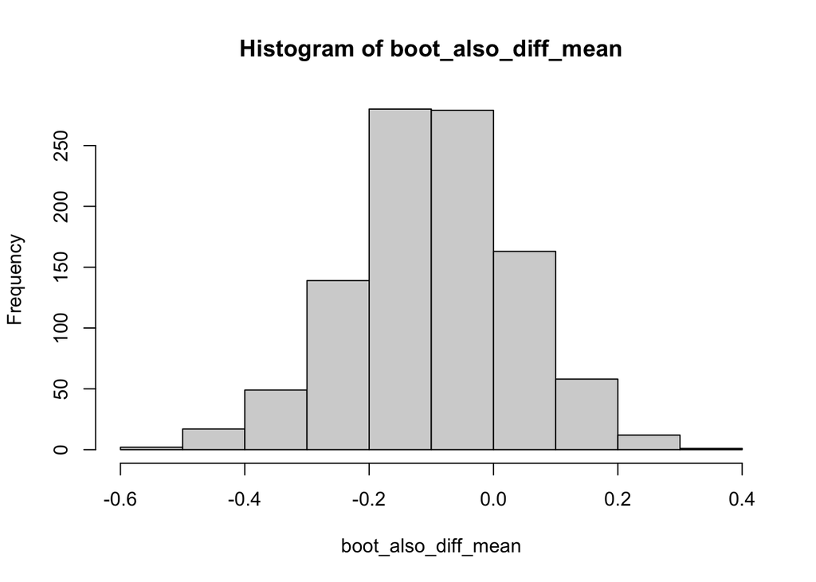

```r
boot_also_diff_mean <- replicate(1000,{
  n_rows <- NROW(London_Milton_also)
  London_Milton_also |>
    sample_n(n_rows, replace = TRUE) |>
    group_by(Author) |>
    summarize(mean_also = mean(also)) |>
    arrange(desc(Author)) |>
    pull(mean_also) |>
    diff()
})
hist(boot_also_diff_mean)
```

```r
sd(boot_also_diff_mean)
```

```
## [1] 0.1356035
```

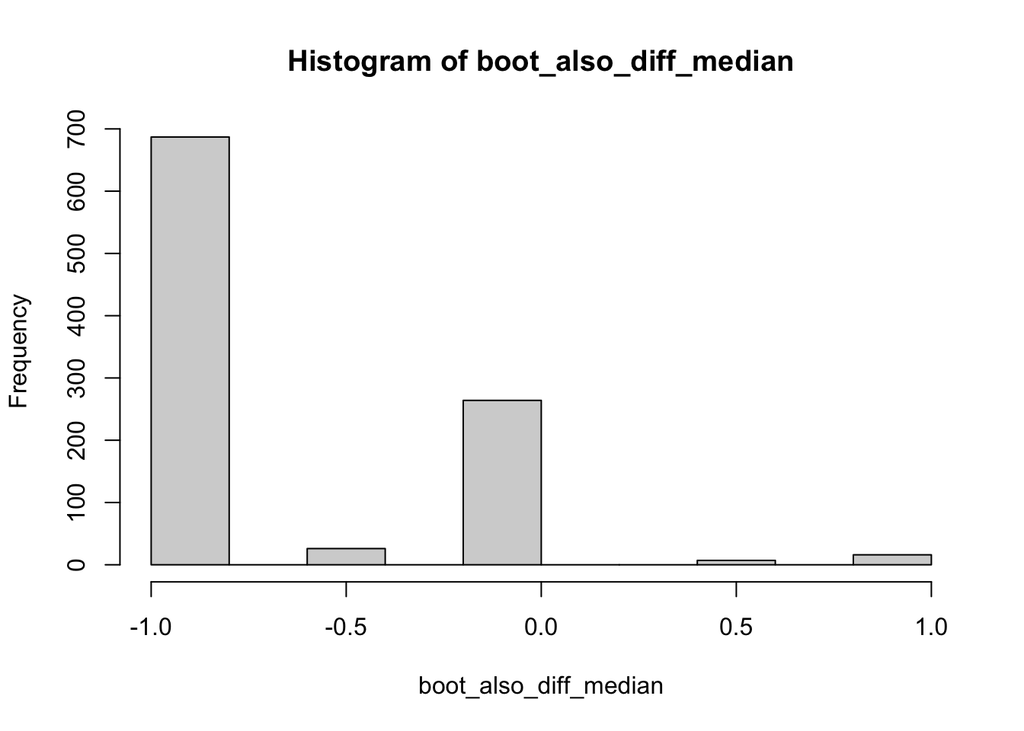

```r
boot_also_diff_median <- replicate(1000,{
  n_rows <- NROW(London_Milton_also)
  London_Milton_also |>
    sample_n(n_rows, replace = TRUE) |>
    group_by(Author) |>
    summarize(median_also = median(also)) |>
    arrange(desc(Author)) |>
    pull(median_also) |>
    diff()
})
hist(boot_also_diff_median)
```

A high p-value and bootstrap models show we can’t entirely reject the null hypothesis as there could be times where the usage of ‘also’ between London and Milton could be the same or different. The difference in means is about 0.09 with a standard deviation of 0.13.

### (Q6d) The word ‘must’ is correlated with the word ‘should’.

```r
cor.test(authors$must,authors$should)
```

```
##
##  Pearson's product-moment correlation
##
## data:  authors$must and authors$should
## t = 11.2, df = 839, p-value < 2.2e-16
## alternative hypothesis: true correlation is not equal to 0
## 95 percent confidence interval:
##  0.3003792 0.4180676
## sample estimates:
##       cor
## 0.3606581
```

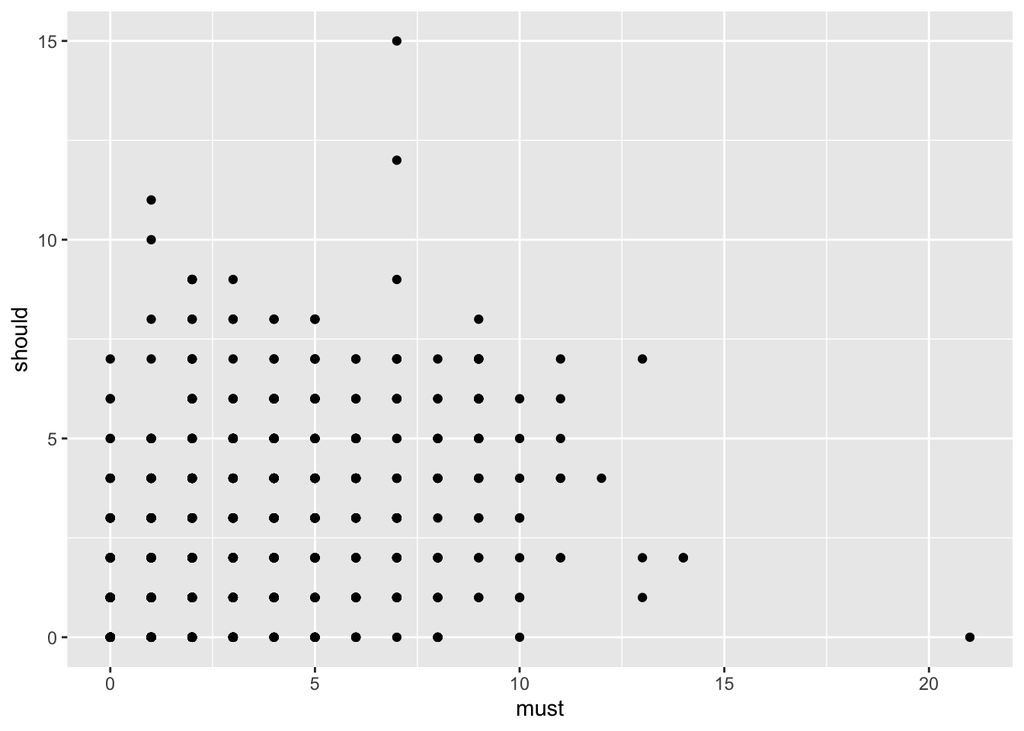

```r
ggplot(authors, aes(x=must,y=should)) + geom_point()
```

### (Q6e) Jane Austen uses the words ‘a’ and ‘the’ at the same rate.

```r
Austen_a_the <- authors |> filter(Author == "Austen") |> select(a,the, Author)
t.test(Austen_a_the$a,Austen_a_the$the)
```

```
##
##  Welch Two Sample t-test
##
## data:  Austen_a_the$a and Austen_a_the$the
## t = -30.003, df = 491.22, p-value < 2.2e-16
## alternative hypothesis: true difference in means is not equal to 0
## 95 percent confidence interval:
##  -31.71921 -27.82022
## sample estimates:
## mean of x mean of y
##  31.23659  61.00631
```

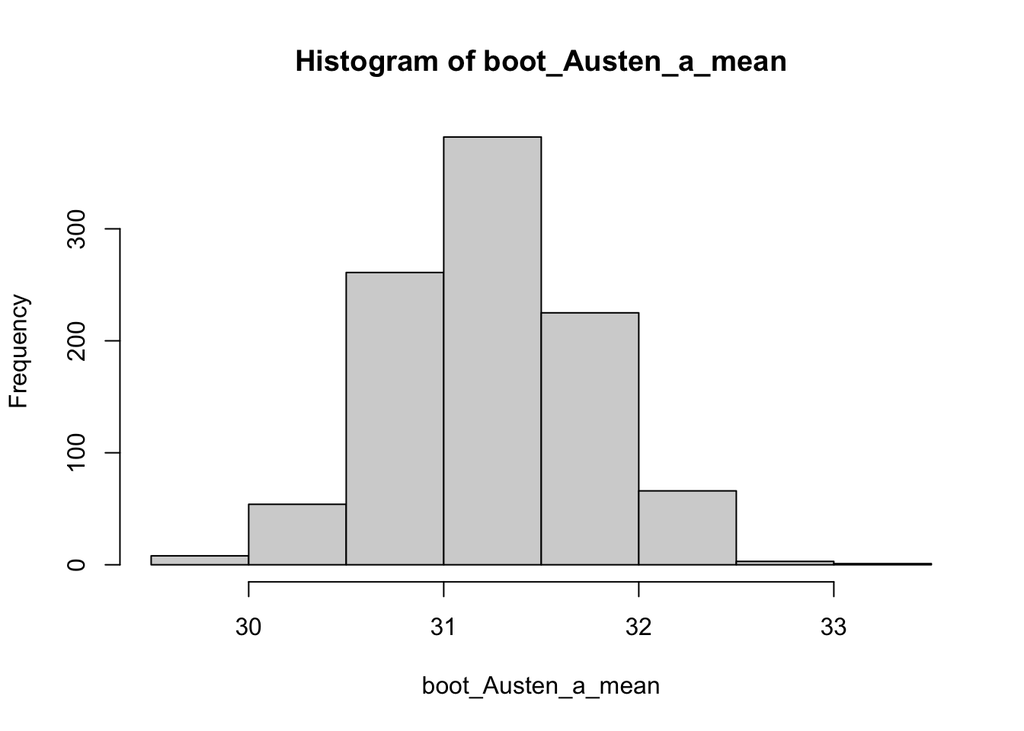

```r
Austen_a <- authors |> filter(Author == "Austen") |> select(a,Author)
boot_Austen_a_mean <- replicate(1000,{
  n_rows <- NROW(Austen_a)
  Austen_a |>
    sample_n(n_rows, replace = TRUE) |>
    summarize(mean_a = mean(a)) |>
    pull(mean_a)
})
hist(boot_Austen_a_mean)
```

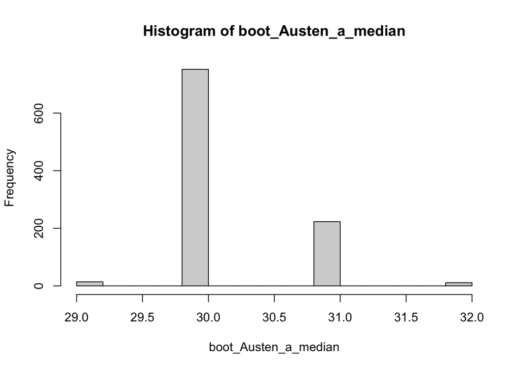

```r
boot_Austen_a_median <- replicate(1000,{
  n_rows <- NROW(Austen_a)
  Austen_a |>
    sample_n(n_rows, replace = TRUE) |>
    summarize(median_a = median(a)) |>
    pull(median_a)
})
hist(boot_Austen_a_median)
```

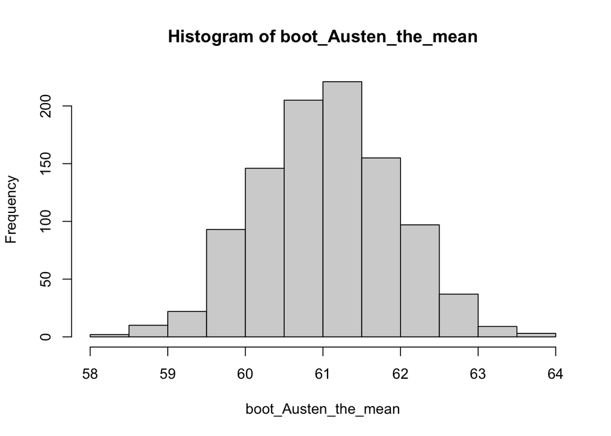

```r
Austen_the <- authors |> filter(Author == "Austen") |> select(the, Author)
boot_Austen_the_mean <- replicate(1000,{
  n_rows <- NROW(Austen_the)
  Austen_the |>
    sample_n(n_rows, replace = TRUE) |>
    summarize(mean_the = mean(the)) |>
    pull(mean_the)
})
hist(boot_Austen_the_mean)
```

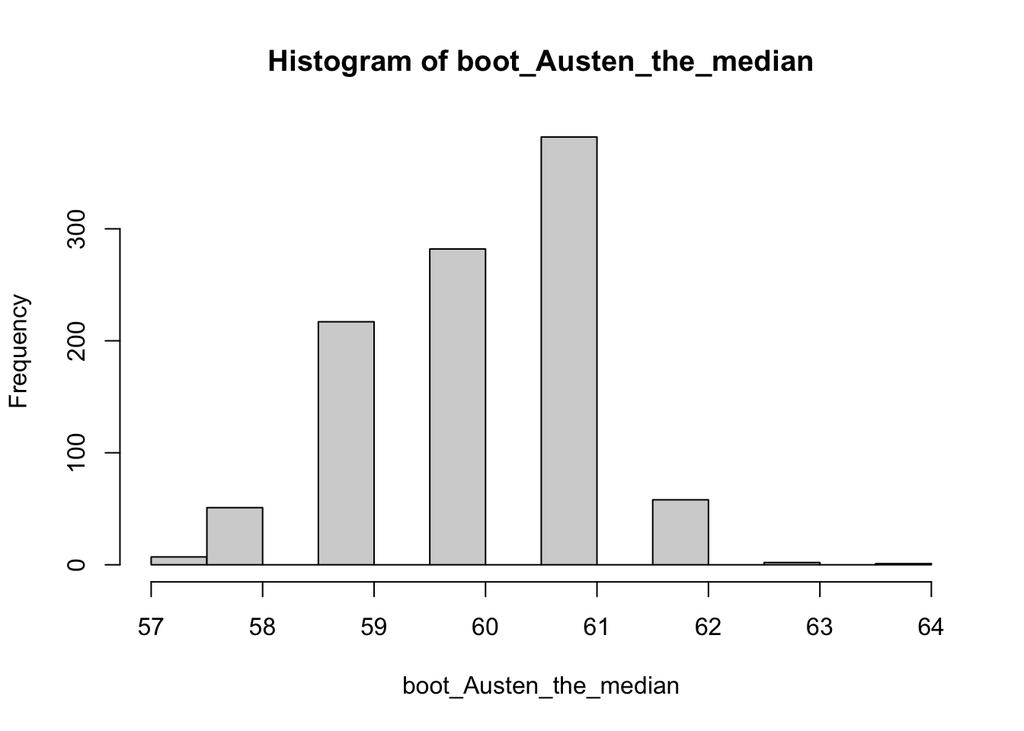

```r
boot_Austen_the_median <- replicate(1000,{
  n_rows <- NROW(Austen_the)
  Austen_the |>
    sample_n(n_rows, replace = TRUE) |>
    summarize(median_the = median(the)) |>
    pull(median_the)
})
hist(boot_Austen_the_median)
```

The t-test and bootstrap models show that Austen uses ‘a’ on average 31 times and uses ‘the’ on average 61 times. The small p-value supports the alternative hypothesis that the true difference in means is not equal to 0. Therefore, Austen does not use the words ‘a’ and ‘the’ at the same rate.

## Question 7

### • Perform a test/train split of the data.

```r
DATA_split = initial_split(authors, prop = 0.8)
DATA_training = training(DATA_split)
Data_testing = testing(DATA_split)
```

### • Fit K-Nearest Neighbors with the author identity as the response.

```r
knn_spec <- nearest_neighbor(neighbors = 5, weight_func = 'triangular') |>
            set_mode("classification") |>
            set_engine("kknn")

wflow_knn <- workflow() |>
             add_formula(Author ~ .) |>
             add_model(knn_spec)

predictor_knn <- fit(wflow_knn,data=DATA_training)
predictor_knn
```

```
## ══ Workflow [trained] ══════════════════════════════════════════════════════════
## Preprocessor: Formula
## Model: nearest_neighbor()
##
## ── Preprocessor ────────────────────────────────────────────────────────────────
## Author ~ .
##
## ── Model ───────────────────────────────────────────────────────────────────────
##
## Call:
## kknn::train.kknn(formula = ..y ~ ., data = data, ks = min_rows(5,     data, 5), kernel = ~"triangular")
##
## Type of response variable: nominal
## Minimal misclassification: 0.004464286
## Best kernel: triangular
## Best k: 5
```

### • Use hyperparameter tuning to identify the best value of K.

```r
knn_spec_tuning <- nearest_neighbor(neighbors = tune()) |>
                   set_mode("classification") |>
                   set_engine("kknn")

knn_grid <- grid_regular(neighbors(), levels = 5)

wflow_knn_tuning <- workflow() |>
  add_formula(Author ~ .) |>
  add_model(knn_spec_tuning)

author_cv <- vfold_cv(DATA_training, v=5)

tuning_results <- wflow_knn_tuning |>
                  tune_grid(resamples = author_cv, grid = knn_grid)

best_knn <- tuning_results |> select_best(metric = "accuracy")
predictor_best_knn <- wflow_knn_tuning |> finalize_workflow(best_knn) |> fit(DATA_training)
predictor_best_knn
```

```
## ══ Workflow [trained] ══════════════════════════════════════════════════════════
## Preprocessor: Formula
## Model: nearest_neighbor()
##
## ── Preprocessor ────────────────────────────────────────────────────────────────
## Author ~ .
##
## ── Model ───────────────────────────────────────────────────────────────────────
##
## Call:
## kknn::train.kknn(formula = ..y ~ ., data = data, ks = min_rows(10L,     data, 5))
##
## Type of response variable: nominal
## Minimal misclassification: 0.00297619
## Best kernel: optimal
## Best k: 10
```

### • Compute and report classification accuracy on both the training and test sets.

```r
#Accuracy test Training Data
augment(predictor_best_knn,DATA_training) |>
  select(Author,.pred_class) |>
  accuracy(estimate=.pred_class,truth=Author)
```

```
## # A tibble: 1 × 3
##   .metric  .estimator .estimate
##   <chr>    <chr>          <dbl>
## 1 accuracy multiclass     0.999
```

```r
#Accuracy test Testing Data
augment(predictor_best_knn,Data_testing) |>
  select(Author,.pred_class) |>
  accuracy(estimate=.pred_class,truth=Author)
```

```
## # A tibble: 1 × 3
##   .metric  .estimator .estimate
##   <chr>    <chr>          <dbl>
## 1 accuracy multiclass     0.988
```